# SIG18 sPCA program annotation

EYW

2026-09-05

```r
library(tidyverse)
```

```r
library(patchwork)
library(viridisLite)
library(ggrepel)
library(ComplexHeatmap)
library(circlize)
library(RColorBrewer)
library(ggpointdensity)
library(scales)
library(viridisLite)
knitr::opts_chunk$set(echo = TRUE)
set.seed(314)
```

```r
source("../../functions/r_custom/plotting_fxns.R")
theme_set(theme_Publication())
interaction_palette <- c("#808080",brewer.pal(5,"Dark2"))
names(interaction_palette) <- c("none", "additive over saturation", "buffering",
                      "buffering complete", "synergy negative", "synergy positive")
```

# Goal

- remove components correlated with technical factors
- annotate sparse PCA programs based on ligands
- annotate interaction effects in sparse PCA programs

# Import

```r
# import feature scores
features <- readr::read_csv("../../analysis_outs/spca/zscore_degs/zscore_degs_unscaled_alpha10.0_sPCA_components.csv")
colnames(features)[-1] <- paste0("comp_",colnames(features)[-1])

# import ligand component values
codes <- readr::read_csv("../../analysis_outs/spca/zscore_degs/zscore_degs_alpha10.0_waggr_score.csv")
codes <- codes %>%
  separate(interaction, into = c("ligand1","ligand2","replicate","sex","well","library","project"), sep = "_") %>%
  dplyr::select(-c(library, project)) %>%
  mutate(interaction = paste0(ligand1, "_", ligand2))
metadata <- read_csv("../../processing_outs/processed_metadata_SIG18.csv")
interScored <- read_csv("../../analysis_outs/deg/interScored_SIG18.csv")
```

# Component Gene Numbers

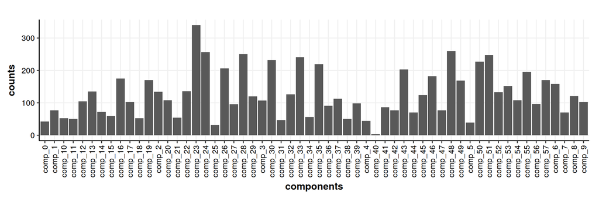

```r
compNum <- features[,-1]
compNum <- tibble(components = names(compNum),
                  counts = colSums(compNum != 0))
ggplot(compNum, aes(x = components, y = counts)) +
  geom_col() +
  theme(axis.text.x = element_text(angle = 90, vjust = 0.5, hjust = 1))
```

```r
compNum %>% nrow()
```

```
## [1] 58
```

# LM for sPCA components

P-value adjustment is performed across each globally.

I will perform lm with a robust covariance model given the lm assumption violations.

```r
library(performance)
library(broom)
library(sandwich)   # robust vcov
library(MASS)       # rlm
library(quantreg)   # rq
# center/scale and clean codes
mat <- codes %>%
  left_join(metadata) %>%
  mutate(sample = paste(ligand1,ligand2,replicate, total_reads_counts, seq_saturation, sep = "_")) %>%
  dplyr::mutate(across(starts_with("comp_"), ~ as.numeric(scale(.x)))) %>%
  column_to_rownames("sample") %>%
  dplyr::select(starts_with("comp_")) %>%
  as.matrix()
# Extract metadata from rownames
meta <- tibble(sample = rownames(mat)) %>%
  separate(sample, into = c("ligand1", "ligand2", "replicate","total_reads_counts", "seq_saturation"), sep = "_", remove = FALSE) %>%
  mutate(
    replicate = factor(replicate),
    ligand1   = fct_relevel(ligand1, "Th0"),
    ligand2   = fct_relevel(ligand2, "none"),
    total_reads_counts = as.vector(scale(as.numeric(total_reads_counts))),
    seq_saturation = as.vector(scale(as.numeric(seq_saturation)))
  )

# Long format
df <- as.data.frame(mat) %>%
  rownames_to_column("sample") %>%
  left_join(meta, by = "sample") %>%
  pivot_longer(cols = starts_with("comp"), names_to = "component", values_to = "loading")
```

## OLS regression

```r
# ---------- Model 1: loading ~ ligand1 * ligand2 + replicate ----------
interaction_models <- df %>%
  group_by(component) %>%
  nest() %>%
  mutate(
    model  = map(data, ~ lm(loading ~ ligand1 * ligand2 + replicate + total_reads_counts + seq_saturation, data = .x)),
    tidy   = map(model, tidy),
    glance = map(model, glance),
    augment= map(model, augment)
  )
# Coefficient table with BH adjust (by term across all components)
lm_interaction <- interaction_models %>%
  dplyr::select(component, tidy) %>%
  unnest(tidy) %>%
  mutate(p_adj = p.adjust(p.value, method = "BH"))
```

```r
for(i in 1:length(interaction_models$model)){
  print(check_heteroskedasticity(interaction_models$model[[i]]))
}
```

```
## Warning: Heteroscedasticity (non-constant error variance) detected (p < .001).
## Warning: Heteroscedasticity (non-constant error variance) detected (p = 0.034).
## OK: Error variance appears to be homoscedastic (p = 0.275).
## OK: Error variance appears to be homoscedastic (p = 0.614).
## OK: Error variance appears to be homoscedastic (p = 0.069).
## Warning: Heteroscedasticity (non-constant error variance) detected (p = 0.002).
## OK: Error variance appears to be homoscedastic (p = 0.631).
## Warning: Heteroscedasticity (non-constant error variance) detected (p = 0.015).
## Warning: Heteroscedasticity (non-constant error variance) detected (p = 0.041).
## OK: Error variance appears to be homoscedastic (p = 0.828).
## Warning: Heteroscedasticity (non-constant error variance) detected (p = 0.002).
## Warning: Heteroscedasticity (non-constant error variance) detected (p < .001).
## OK: Error variance appears to be homoscedastic (p = 0.051).
## Warning: Heteroscedasticity (non-constant error variance) detected (p = 0.006).
## Warning: Heteroscedasticity (non-constant error variance) detected (p < .001).
## OK: Error variance appears to be homoscedastic (p = 0.441).
## Warning: Heteroscedasticity (non-constant error variance) detected (p < .001).
## OK: Error variance appears to be homoscedastic (p = 0.768).
## Warning: Heteroscedasticity (non-constant error variance) detected (p < .001).
## OK: Error variance appears to be homoscedastic (p = 0.269).
## OK: Error variance appears to be homoscedastic (p = 0.507).
## Warning: Heteroscedasticity (non-constant error variance) detected (p < .001).
## Warning: Heteroscedasticity (non-constant error variance) detected (p = 0.002).
## Warning: Heteroscedasticity (non-constant error variance) detected (p < .001).
## Warning: Heteroscedasticity (non-constant error variance) detected (p < .001).
## OK: Error variance appears to be homoscedastic (p = 0.187).
## OK: Error variance appears to be homoscedastic (p = 0.219).
## Warning: Heteroscedasticity (non-constant error variance) detected (p = 0.011).
## OK: Error variance appears to be homoscedastic (p = 0.492).
## Warning: Heteroscedasticity (non-constant error variance) detected (p < .001).
## OK: Error variance appears to be homoscedastic (p = 0.139).
## Warning: Heteroscedasticity (non-constant error variance) detected (p = 0.021).
## Warning: Heteroscedasticity (non-constant error variance) detected (p = 0.008).
## OK: Error variance appears to be homoscedastic (p = 0.493).
## OK: Error variance appears to be homoscedastic (p = 0.842).
## OK: Error variance appears to be homoscedastic (p = 0.587).
## OK: Error variance appears to be homoscedastic (p = 0.711).
## OK: Error variance appears to be homoscedastic (p = 0.273).
## OK: Error variance appears to be homoscedastic (p = 0.109).
## Warning: Heteroscedasticity (non-constant error variance) detected (p = 0.013).
## Warning: Heteroscedasticity (non-constant error variance) detected (p < .001).
## OK: Error variance appears to be homoscedastic (p = 0.279).
## OK: Error variance appears to be homoscedastic (p = 0.143).
## OK: Error variance appears to be homoscedastic (p = 0.791).
## OK: Error variance appears to be homoscedastic (p = 0.100).
## Warning: Heteroscedasticity (non-constant error variance) detected (p < .001).
## Warning: Heteroscedasticity (non-constant error variance) detected (p = 0.041).
## OK: Error variance appears to be homoscedastic (p = 0.311).
## OK: Error variance appears to be homoscedastic (p = 0.239).
## OK: Error variance appears to be homoscedastic (p = 0.479).
## OK: Error variance appears to be homoscedastic (p = 0.074).
## OK: Error variance appears to be homoscedastic (p = 0.221).
## Warning: Heteroscedasticity (non-constant error variance) detected (p = 0.026).
## Warning: Heteroscedasticity (non-constant error variance) detected (p < .001).
## Warning: Heteroscedasticity (non-constant error variance) detected (p < .001).
## Warning: Heteroscedasticity (non-constant error variance) detected (p < .001).
## Warning: Heteroscedasticity (non-constant error variance) detected (p = 0.016).
```

## Regression with Robust SE

Due to the OLS assumption violations, I will redo the regression using robust standard errors.

```r
# ---- Robust covariance helpers ----
# Robust SE
.robust_vcov <- function(mod) sandwich::vcovHC(mod, type = "HC3")

.tidy_ols_hc <- function(mod) broom::tidy(mod, conf.int = TRUE, vcov = .robust_vcov(mod))

# Robust estimation (Huber) — coefficients may shift if outliers matter
.fit_rlm <- function(d, fml) MASS::rlm(fml, data = d, psi = psi.huber)
.tidy_rlm <- function(mod) broom::tidy(mod)  # treat as sensitivity (SEs are large-sample)

# =========================
# Model 1: loading ~ ligand1 * ligand2 + replicate
# =========================
interaction_models <- df %>%
  group_by(component) %>%
  nest() %>%
  mutate(
    model_ols   = map(data, ~ lm(loading ~ ligand1 * ligand2 + replicate + total_reads_counts + seq_saturation, data = .x)),
    tidy_ols_hc = map(model_ols, .tidy_ols_hc),
    glance_ols  = map(model_ols, glance),
    augment_ols = map(model_ols, augment),

    model_rlm   = map(data, ~ .fit_rlm(.x, loading ~ ligand1 * ligand2 + replicate + total_reads_counts + seq_saturation)),
    tidy_rlm    = map(model_rlm, .tidy_rlm)
  )

# OLS+HC coefficient table with BH adjust globally
lm_interaction <- interaction_models %>%
  dplyr::select(component, tidy_ols_hc) %>%
  unnest(tidy_ols_hc) %>%
  ungroup() %>%
  mutate(p_adj = p.adjust(p.value, method = "BH"))

rlm_interaction <- interaction_models %>%
  dplyr::select(component, tidy_rlm) %>%
  unnest(tidy_rlm)
```

## Compare RLM to LM

```r
joint_interaction <- left_join(lm_interaction, rlm_interaction,
                               by = c("component","term"),
                               suffix = c("_lm","_rlm"))
```

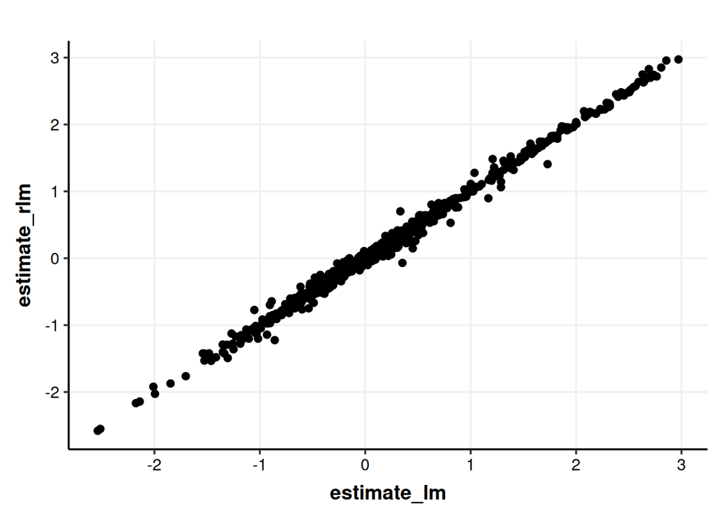

```r
joint_interaction %>%
  ggplot(aes(x = estimate_lm, y = estimate_rlm)) +
    geom_point()
```

It seems like the coefficients are pretty similar between the lm and robust lm so I will stick to lm

## Identify replicate-driven components

Here, I want to identify and remove components that are primarily driven by technical factors. This will specifically manifest as those that are highly associated with technical replicates

### Visualize replicate associations

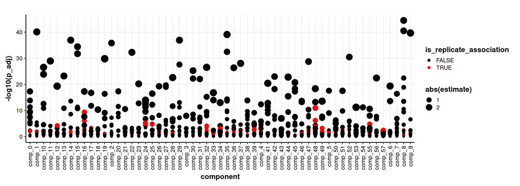

```r
lm_interaction %>%
  #filter(p_adj < 0.01) %>%
  mutate(is_replicate_association = grepl("replicate", term)) %>%
  ggplot(aes(x = component, y = -log10(p_adj), color = is_replicate_association, size = abs(estimate))) +
  geom_point() +
  scale_color_manual(values = c("FALSE" = "black", "TRUE" = "red")) +
  theme(axis.text.x = element_text(angle = 90, hjust = 1, vjust=0.5))
```

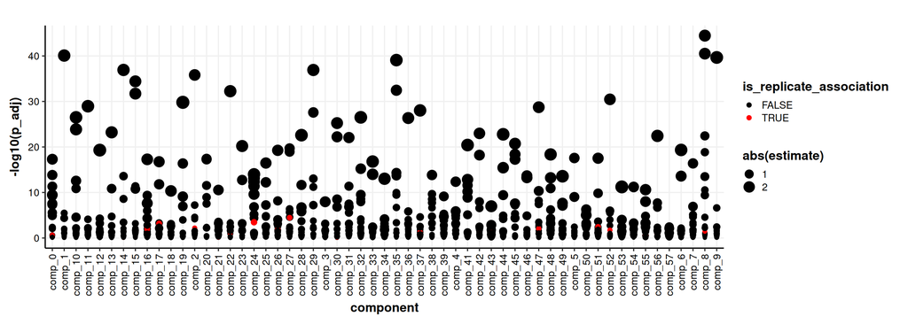

```r
lm_interaction %>%
  #filter(p_adj < 0.01) %>%
  mutate(is_replicate_association = grepl("total_reads_counts", term)) %>%
  ggplot(aes(x = component, y = -log10(p_adj), color = is_replicate_association, size = abs(estimate))) +
  geom_point() +
  scale_color_manual(values = c("FALSE" = "black", "TRUE" = "red")) +
  theme(axis.text.x = element_text(angle = 90, hjust = 1, vjust=0.5))
```

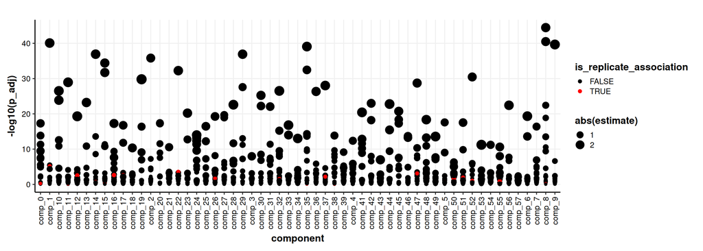

```r
lm_interaction %>%
  #filter(p_adj < 0.01) %>%
  mutate(is_replicate_association = grepl("seq_saturation", term)) %>%
  ggplot(aes(x = component, y = -log10(p_adj), color = is_replicate_association, size = abs(estimate))) +
  geom_point() +
  scale_color_manual(values = c("FALSE" = "black", "TRUE" = "red")) +
  theme(axis.text.x = element_text(angle = 90, hjust = 1, vjust=0.5))
```

### Filter replicate-driven componets

I will take a conservative approach and remove any component where the most significant association is replicate

```r
bad_rep_comps <- lm_interaction %>%
  group_by(component) %>%
  slice_min(p_adj, with_ties = FALSE) %>%
  filter(grepl("replicate", term)) %>%
  pull(component)

bad_rep_comps
```

```
## [1] "comp_57"
```

```r
# make filtered lm tibble
lm_interaction_filtered <- lm_interaction %>%
  filter(!(component %in% bad_rep_comps))
```

## Classify interaction effects

Here, I will take a similar approach as in the gene-level analysis and identify synergy, buffering and purely additive effects

```r
# make formated tibble
l1 <- lm_interaction_filtered %>%
  filter(grepl("^ligand1", term)) %>%
  transmute(component,
            ligand1 = sub("^ligand1", "", term),
            estimate_ligand1 = estimate,
            p_adj_ligand1 = p_adj)
l2 <- lm_interaction_filtered %>%
  filter(grepl("^ligand2", term)) %>%
  transmute(component,
            ligand2 = sub("^ligand2", "", term),
            estimate_ligand2 = estimate,
            p_adj_ligand2 = p_adj)
int <- lm_interaction_filtered %>%
  filter(grepl("^ligand1.+:ligand2", term)) %>%
  separate(term, c("l1","l2"), sep = ":", remove = FALSE) %>%
  transmute(component,
            ligand1 = sub("^ligand1", "", l1),
            ligand2 = sub("^ligand2", "", l2),
            interaction = paste0(ligand1, "_", ligand2),
            estimate_interaction = estimate,
            p_adj_interaction = p_adj)

# assemble
out <- int %>%
  left_join(l1, by = c("component","ligand1"), relationship = "many-to-many") %>%
  left_join(l2, by = c("component","ligand2"), relationship = "many-to-many") %>%
  arrange(component, ligand1, ligand2)
```

```r
lm_scored <- out %>%
  mutate(estimate_total_interaction_model = (estimate_ligand1+estimate_ligand2+estimate_interaction),
         interaction_score = case_when(p_adj_interaction > 0.1 ~ 0,
                                       p_adj_interaction <= 0.1 ~ (estimate_interaction/(estimate_total_interaction_model)))) %>%
    mutate(interaction_class = case_when(
        # conditions are evaluated sequentially
        p_adj_interaction <= 0.1 & estimate_total_interaction_model > 0 & interaction_score > 0 ~ "synergy positive",
        p_adj_interaction <= 0.1 & estimate_total_interaction_model < 0 & interaction_score > 0 ~ "synergy negative",
        p_adj_interaction <= 0.1 & interaction_score < 0 ~ "buffering",
        p_adj_interaction > 0.1 ~ "none"
        ))
```

### Merge with gene-level analysis

Here I will merge the program features with the gene-level analysis of interaction effects which is more reliable

```r
spca_genes <- features %>%
  pivot_longer(-gene, names_to = "spca_component", values_to = "loading") %>%
  filter(loading != 0) %>%
  arrange(spca_component,desc(loading))

# pivot interscored so interaction class for each TNF interactor is a column
gene_interactions <- interScored %>%
  pivot_wider(id_cols = c(name),
              names_from = ligand1,
              names_prefix = "interaction_",
              values_from = interaction_class)

# create annotated spca genes file
spca_genes_anno <- spca_genes %>%
  left_join(gene_interactions, by = join_by(gene == name))
```

```r
interScored_minimal <- interScored %>%
  dplyr::select(name, interaction, interaction_class) %>%
  mutate(interaction = gsub("\\.","_", interaction)) %>%
  rename(interaction_class_gene = interaction_class)

# create annotated lm_scored with proportion of synergy and buffering
# genes out of total for every component and interaction
lm_scored_anno <- lm_scored %>%
  left_join(spca_genes, by = c("component" = "spca_component"), relationship = "many-to-many") %>%
  left_join(interScored_minimal, by = c("gene" = "name","interaction")) %>%
  group_by(across(-c(gene, loading, interaction_class_gene))) %>%
  count(interaction_class_gene, name = "n") %>%
  mutate(prop = n / sum(n))  %>%
  ungroup() %>%
  filter(interaction_class_gene != "none") %>%
  pivot_wider(id_cols = -n,
              names_from = interaction_class_gene,
              names_prefix = "freq_",
              values_from = prop,
              values_fill = 0)
```

# Export

```r
# export loadings of components with gene-level synergies
write_csv(spca_genes_anno, "../../analysis_outs/spca/zscore_degs_alpha10.0_sPCA_loadings.csv")
```

```r
write_csv(lm_interaction, "../../analysis_outs/spca/lm_fit_zscore_degs_alpha10.0_sPCA.csv")
write_csv(lm_interaction_filtered, "../../analysis_outs/spca/lm_fit_zscore_degs_alpha10.0_sPCA_clean.csv")
write_csv(lm_scored_anno, "../../analysis_outs/spca/lm_scored_zscore_degs_alpha10.0_sPCA_clean.csv")
```